# Corona - Fallzahlenauswertung

### Datenquelle, Abrufzeitpunkt

[Link zur Datenbeschreibung des RKI](https://www.arcgis.com/home/item.html?id=dd4580c810204019a7b8eb3e0b329dd6)

| Amtliche RKI-Corona-Daten für Land-/Stadtkreis | Abrufzeitpunkt |
| --- | --- |
| Passau, kreisfreie Stadt | Freitag, 09.04.2021, 07:24:57 |

### Inzidenzrelevanter Zeitraum

| von - bis | nicht mehr in der Inzidenzzahl |
| --- | --- |
| Fr, 02.04.2021 - Do, 08.04.2021 | Do, 01.04.2021 und älter |

### Veränderungen zum Vortag

```
##  Meldedatum Art Inzidenzrelevant Fallzahl A05-A14 A15-A34 A35-A59 A60-A79
##  2021-04-07 Neu               Ja        6       0       3       2       1
##  2021-04-08 Neu               Ja        9       1       4       2       2
```

### Altersstruktur der aktuellen 7-Tage-Inzidenzfälle

```
##  A00-A04 A05-A14 A15-A34 A35-A59 A60-A79
##        1       6      29      17      11
```

### Wochenübersicht

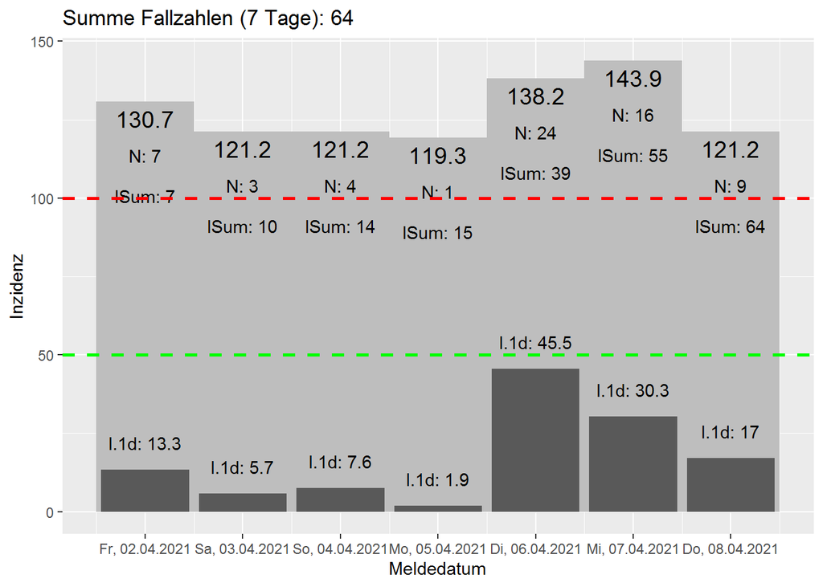

Erläuterung der Zahlenangaben:  
**N**: Anzahl der neu und nachträglich gemeldeten abzüglich der gestrichenen Fälle des jeweiligen Tages  
**I.1d** (“1-Tages-Inzidenz”): Höhe des Beitrags, den dieser Tag zur Wocheninzidenz leistet  
**lSum**: Aggregierte Summe der Fallzahlen über den Verlauf der beobachteten Woche. Der erste Tag entspricht diesem einzelnen Tag (und fällt als nächstes aus der Inzidenz), der letzte Tag entspricht der Wochen-Inzidenz.

### Über-/Unterschreitungen der geltenden Grenzwerte

```
##  Grenzwert bei_Fallzahl Abweichung
##         50           26        +38
##        100           52        +12
```

### Gesicherter Ausblick (absehbare Streichungen)

Aktuelle Inzidenz: 121.2, basierend auf den insgesamt 64 Fällen der letzten Woche.

[output not shown]

Die Fallzahlen der nächsten Tage sowie eventuelle Nachmeldungen sind dabei nicht vorhersehbar. Der maximale Rückgang wird nur erreicht, wenn bis zu diesem Tag per Saldo kein neuer Fall erfasst wird.

### Ungesicherter Ausblick

Fallzahlen gehen je nach Wochentag in unterschiedlicher Höhe ein. Basierend auf den letzten 3 Wochen bzw. 21 Tagen ergibt sich folgende Verteilung:

```
##   Wochentag Fallzahl_Durchschnitt DoW
##     Sonntag                  4.67   1
##      Montag                  3.00   2
##    Dienstag                 17.67   3
##    Mittwoch                 15.67   4
##  Donnerstag                 13.00   5
##     Freitag                 14.67   6
##     Samstag                  6.00   7
```

…auf der Grundlage folgender Fallzahlen der letzten 3 Wochen:

```
##  Meldedatum AnzahlFall  Wochentag
##  2021-03-19         23    Freitag
##  2021-03-20          7    Samstag
##  2021-03-21          6    Sonntag
##  2021-03-22          6     Montag
##  2021-03-23         15   Dienstag
##  2021-03-24         18   Mittwoch
##  2021-03-25          9 Donnerstag
##  2021-03-26         14    Freitag
##  2021-03-27          8    Samstag
##  2021-03-28          4    Sonntag
##  2021-03-29          2     Montag
##  2021-03-30         14   Dienstag
##  2021-03-31         13   Mittwoch
##  2021-04-01         21 Donnerstag
##  2021-04-02          7    Freitag
##  2021-04-03          3    Samstag
##  2021-04-04          4    Sonntag
##  2021-04-05          1     Montag
##  2021-04-06         24   Dienstag
##  2021-04-07         16   Mittwoch
##  2021-04-08          9 Donnerstag
```

### Blick in die Kristallkugel

Hier werden drei verschiedene Szenarien dargestellt:  
* Optimistische Variante 0 (Grün): Es treten keine Fälle mehr auf, somit dauert es noch 7 Tage, bis alle Inzidenzfälle abgeschmolzen sind.  
* Realistische Variante 1 (schwarz): Täglich kommen die durchschnittlichen Fälle für den jeweiligen Wochentag hinzu, was dem Abschmelzen aus Variante 0 entgegenwirkt.  
* Pessimistische Variante 2 (Rot): Wie Variante 1, nur kommt täglich der DOPPELTE Durchschnitt für den jeweiligen Wochentag hinzu. Dieser Zuwachs stellt keineswegs das obere Limit des möglichen dar.

**Bitte beachten: Im Folgenden stellt die Zeitachse das Veröffentlichungsdatum dar, nicht das Meldedatum, und ist somit um einen Tag verschoben!**

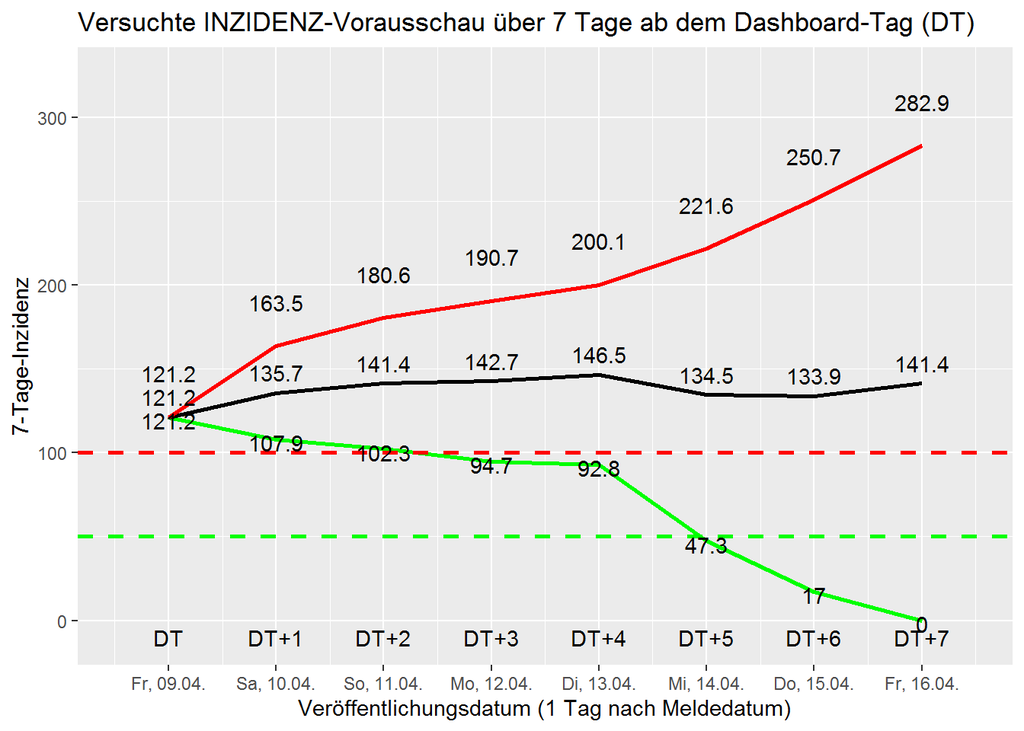

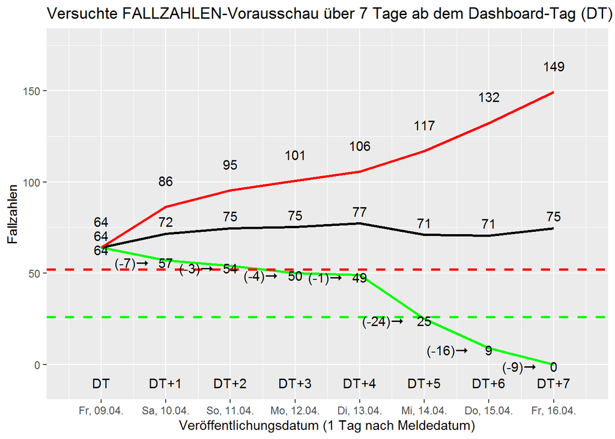